# How Has BMI Changed Among Low-Income Adults?

Findings from a classroom NHANES dataset

Jade Lee

## Question And Audience

**Audience:** Adults in the general public who see an online article or post saying that low income leads to weight gain.

**Question:** Does this chart show that low income leads to weight gain?

**Why it matters:** Before they believe or share it, they need to know what this data can and cannot show.

## Evidence

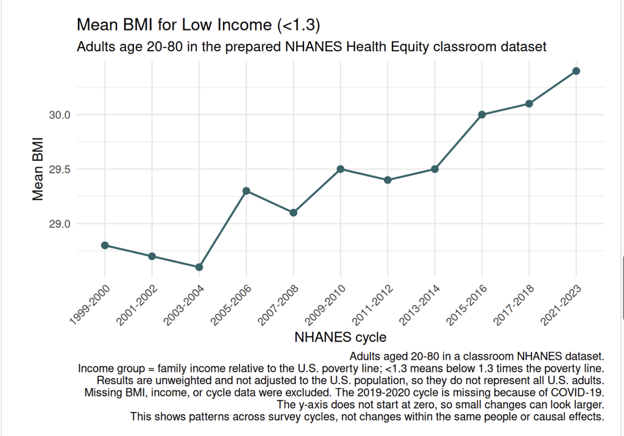

The vertical axis starts near 28.5, not 0, so small changes can look larger. Source: classroom snapshot of CDC/NCHS NHANES data (Centers for Disease Control and Prevention, National Center for Health Statistics 2026).

BMI is a number based on weight and height. A higher BMI means more weight for a person’s height. Average BMI was 28.8 in 1999-2000 and 30.4 in 2021-2023.

**Takeaway:** Average BMI rose by 1.6 points among low-income adults in this dataset, but the chart can’t tell us whether low income caused that rise.

## Limitation And Next Step

**Limitation:** This chart shows only one income group, so it has nothing to compare against. The people surveyed in different years may also have differed in other ways, such as age or diet, which could help explain the rise. The chart alone can’t tell us what caused it.

The data describe only the people in this classroom dataset, not all Americans. BMI also does not fit every body. For example, athletes can have a high BMI from muscle, not poor health.

**Next step:** Before sharing a post that says low income causes weight gain, check which income groups the chart includes and what it measures.

**AI-use note:** AI drafted wording and layout code. I checked every number against my A7 summary table.

## References

Centers for Disease Control and Prevention, National Center for Health Statistics. 2026. *National Health and Nutrition Examination Survey*. https://wwwn.cdc.gov/nchs/nhanes/.